# Project 1 - Applied Statistics

## Author - [Shekar Roy](https://github.com/shekarroy15)

## Datasets - 1, Basketball.csv

### Learning Outcomes

#### Exploratory Data Analysis

#### Practicing statistics using Python

#### Hypothesis testing

```python
## first import packages

import numpy as np
import pandas as pd
import matplotlib.pyplot as plt
%matplotlib inline
import scipy.stats as stats
import seaborn as sns
```

```python
basketball = pd.read_csv('Basketball.csv')
basketball.head(5)
```

|  | Team | Tournament | Score | PlayedGames | WonGames | DrawnGames | LostGames | BasketScored | BasketGiven | TournamentChampion | Runner-up | TeamLaunch | HighestPositionHeld |
| --- | --- | --- | --- | --- | --- | --- | --- | --- | --- | --- | --- | --- | --- |
| 0 | Team 1 | 86 | 4385 | 2762 | 1647 | 552 | 563 | 5947 | 3140 | 33 | 23 | 1929 | 1 |
| 1 | Team 2 | 86 | 4262 | 2762 | 1581 | 573 | 608 | 5900 | 3114 | 25 | 25 | 1929 | 1 |
| 2 | Team 3 | 80 | 3442 | 2614 | 1241 | 598 | 775 | 4534 | 3309 | 10 | 8 | 1929 | 1 |
| 3 | Team 4 | 82 | 3386 | 2664 | 1187 | 616 | 861 | 4398 | 3469 | 6 | 6 | 1931to32 | 1 |
| 4 | Team 5 | 86 | 3368 | 2762 | 1209 | 633 | 920 | 4631 | 3700 | 8 | 7 | 1929 | 1 |

```python
# Replacing - with zero
basketball = basketball.replace('-',0)
basketball.head(5)
```

|  | Team | Tournament | Score | PlayedGames | WonGames | DrawnGames | LostGames | BasketScored | BasketGiven | TournamentChampion | Runner-up | TeamLaunch | HighestPositionHeld |
| --- | --- | --- | --- | --- | --- | --- | --- | --- | --- | --- | --- | --- | --- |
| 0 | Team 1 | 86 | 4385 | 2762 | 1647 | 552 | 563 | 5947 | 3140 | 33 | 23 | 1929 | 1 |
| 1 | Team 2 | 86 | 4262 | 2762 | 1581 | 573 | 608 | 5900 | 3114 | 25 | 25 | 1929 | 1 |
| 2 | Team 3 | 80 | 3442 | 2614 | 1241 | 598 | 775 | 4534 | 3309 | 10 | 8 | 1929 | 1 |
| 3 | Team 4 | 82 | 3386 | 2664 | 1187 | 616 | 861 | 4398 | 3469 | 6 | 6 | 1931to32 | 1 |
| 4 | Team 5 | 86 | 3368 | 2762 | 1209 | 633 | 920 | 4631 | 3700 | 8 | 7 | 1929 | 1 |

```python
# find the basket difference

basketball['BasketScored'] = basketball.BasketScored.astype(float)
basketball['BasketGiven'] = basketball.BasketGiven.astype(float)
basketball['Difference'] = basketball['BasketScored'] - basketball['BasketGiven']

basketball.head(1)
```

|  | Team | Tournament | Score | PlayedGames | WonGames | DrawnGames | LostGames | BasketScored | BasketGiven | TournamentChampion | Runner-up | TeamLaunch | HighestPositionHeld | Difference |
| --- | --- | --- | --- | --- | --- | --- | --- | --- | --- | --- | --- | --- | --- | --- |
| 0 | Team 1 | 86 | 4385 | 2762 | 1647 | 552 | 563 | 5947.0 | 3140.0 | 33 | 23 | 1929 | 1 | 2807.0 |

```python
basketball.tail(1)
```

|  | Team | Tournament | Score | PlayedGames | WonGames | DrawnGames | LostGames | BasketScored | BasketGiven | TournamentChampion | Runner-up | TeamLaunch | HighestPositionHeld | Difference |
| --- | --- | --- | --- | --- | --- | --- | --- | --- | --- | --- | --- | --- | --- | --- |
| 60 | Team 61 | 1 | 0 | 0 | 0 | 0 | 0 | 0.0 | 0.0 | 0 | 0 | 2017~18 | 9 | 0.0 |

```python
basketball['Points'] = pd.to_numeric(basketball['Score'])
basketball.sort_values(by='Points',ascending=False).loc[:4,'Team']
```

```
0    Team 1
1    Team 2
2    Team 3
3    Team 4
4    Team 5
Name: Team, dtype: object
```

```python
basketball['GamesWon'] = pd.to_numeric(basketball['WonGames'])
basketball['GamesPlayed'] = pd.to_numeric(basketball['PlayedGames'])
basketball['PercentageOfWinning(in %)'] = round((basketball['GamesWon']/basketball['GamesPlayed']) * 100,3)
basketball.fillna(0)
basketball.sort_values(by='PercentageOfWinning(in %)',ascending=False).loc[:4,['Team','PercentageOfWinning(in %)']]
```

|  | Team | PercentageOfWinning(in %) |
| --- | --- | --- |
| 0 | Team 1 | 59.631 |
| 1 | Team 2 | 57.241 |
| 2 | Team 3 | 47.475 |
| 3 | Team 4 | 44.557 |
| 4 | Team 5 | 43.773 |

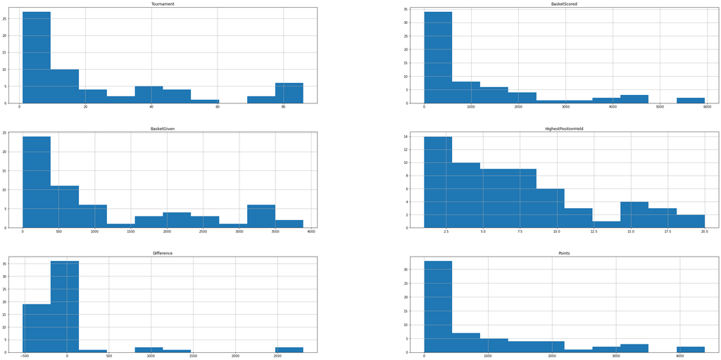

```python
basketball.hist(figsize= (40,20));
```

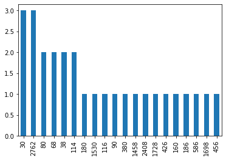

```python
basketball['PlayedGames'].value_counts().head(20).plot.bar();
```

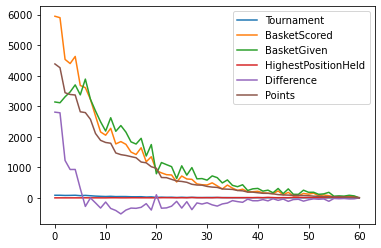

```python
basketball.plot.line();
```

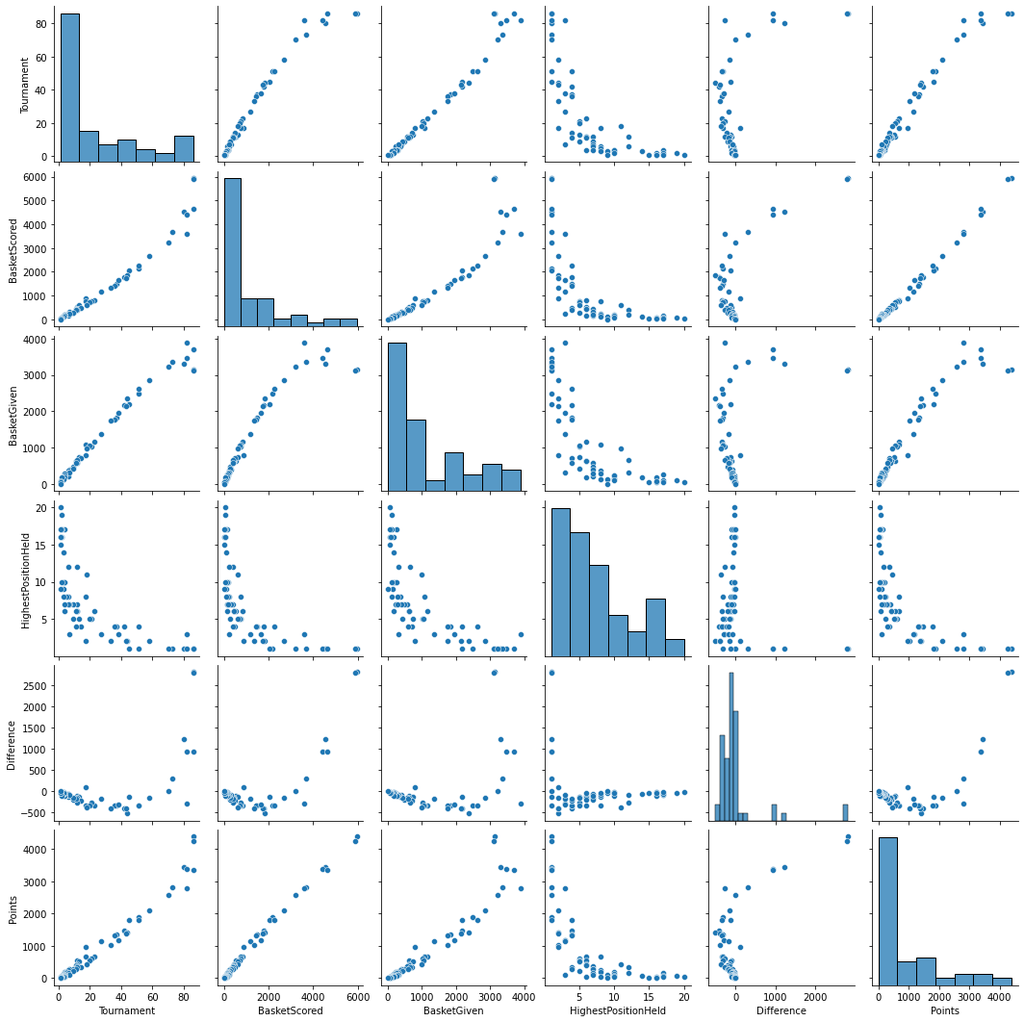

```python
sns.pairplot(data=basketball);
```

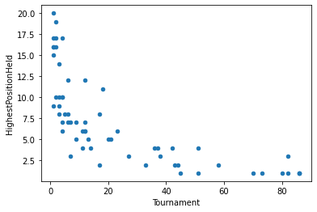

```python
basketball.plot.scatter(x='Tournament', y='HighestPositionHeld');
```

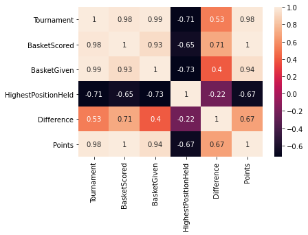

```python
corr = basketball.corr()
corr
sns.heatmap(corr, annot=True);
```

## Datasets - 2, Company_EU.csv

```python
#Imports here

import pandas as pd
%matplotlib inline
from matplotlib import pyplot as plt
import seaborn as sns
from statsmodels.stats.weightstats import ztest
from scipy.stats import ttest_ind
from statsmodels.stats.proportion import proportions_chisquare
from scipy.stats import f_oneway

company = pd.read_csv('CompanyX_EU.csv')
print(company.shape)
company.head()
```

```
(662, 6)
```

|  | Startup | Product | Funding | Event | Result | OperatingState |
| --- | --- | --- | --- | --- | --- | --- |
| 0 | 2600Hz | 2600hz.com | NaN | Disrupt SF 2013 | Contestant | Operating |
| 1 | 3DLT | 3dlt.com | $630K | Disrupt NYC 2013 | Contestant | Closed |
| 2 | 3DPrinterOS | 3dprinteros.com | NaN | Disrupt SF 2016 | Contestant | Operating |
| 3 | 3Dprintler | 3dprintler.com | $1M | Disrupt NY 2016 | Audience choice | Operating |
| 4 | 42 Technologies | 42technologies.com | NaN | Disrupt NYC 2013 | Contestant | Operating |

```python
company.dtypes
```

```
Startup           object
Product           object
Funding           object
Event             object
Result            object
OperatingState    object
dtype: object
```

```python
company.isna().sum()
```

```
Startup             0
Product             6
Funding           214
Event               0
Result              0
OperatingState      0
dtype: int64
```

- Turns out we do not have data of funds raised by all the companies
- We would need need it to perform the first task, hence we will have to ignore the companies of which we do not have data for the funds they raised

```python
modified = company.dropna().copy()
```

```python
modified['Funding'].sample(5)
```

```
524    $200K
390    $3.9M
546     $40M
138     $72M
110    $750K
Name: Funding, dtype: object
```

```python
float(modified.iloc[0,2][1:-1])/1000
```

```
0.63
```

```python
float(modified.iloc[0,2][1:-1])/1000
```

```
0.63
```

```python
modified.loc[:,'Funds_in_million'] = modified['Funding'].apply(lambda x: float(x[1:-1])/1000 if x[-1] == 'K' else (float(x[1:-1])*1000 if x[-1] == 'B' else float(x[1:-1])))
```

```python
modified.sample(3)
```

|  | Startup | Product | Funding | Event | Result | OperatingState | Funds_in_million |
| --- | --- | --- | --- | --- | --- | --- | --- |
| 597 | Twentify | twentify.com | $1M | Disrupt London 2015 | Contestant | Operating | 1.0000 |
| 450 | Relevancy Data | relevancydata.com | $20.3K | Disrupt NY 2015 | Contestant | Operating | 0.0203 |
| 70 | Boomerang Commerce | boomerangcommerce.com | $20.5M | Disrupt NYC 2014 | Finalist | Operating | 20.5000 |

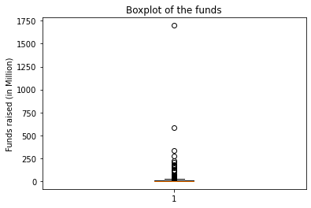

```python
plot = plt.boxplot(modified.Funds_in_million)
plt.title('Boxplot of the funds')
plt.ylabel("Funds raised (in Million)")

plt.show()
```

```python
plot['caps'][1].get_data()
```

```
(array([0.9625, 1.0375]), array([22., 22.]))
```

```python
upper_fence = plot['caps'][1].get_data()[1][1]
upper_fence
```

```
22.0
```

```python
print(f'Number of outliers = {len(modified[modified.Funds_in_million > upper_fence])}')

modified[modified.Funds_in_million > upper_fence]
```

```
Number of outliers = 60
```

|  | Startup | Product | Funding | Event | Result | OperatingState | Funds_in_million |
| --- | --- | --- | --- | --- | --- | --- | --- |
| 6 | 8 Securities | 8securities.com | $29M | Disrupt Beijing 2011 | Finalist | Operating | 29.0 |
| 31 | Anyclip | anyclip.com | $24M | TC50 2009 | Finalist | Operating | 24.0 |
| 40 | Artsy | artsy.net | $50.9M | Disrupt NYC 2010 | Contestant | Operating | 50.9 |
| 49 | Badgeville | badgeville.com | $40M | Disrupt SF 2010 | Finalist | Acquired | 40.0 |
| 56 | Betterment | betterment.com | $205M | Disrupt NYC 2010 | Finalist | Operating | 205.0 |
| 108 | Clickable | clickable.com | $32.5M | TC40 2007 | Finalist | Acquired | 32.5 |
| 113 | Cloudflare | cloudflare.com | $182.1M | Disrupt SF 2010 | Runner up | Operating | 182.1 |
| 128 | Credit Sesame | creditsesame.com | $35.4M | Disrupt SF 2010 | Contestant | Operating | 35.4 |
| 130 | CrowdFlower Inc. | crowdflower.com | $38M | TC50 2009 | Contestant | Operating | 38.0 |
| 132 | Cubic Telecom | cubictelecom.com | $37.1M | TC40 2007 | Contestant | Operating | 37.1 |
| 138 | DataSift | datasift.com | $72M | Disrupt SF 2010 | Finalist | Operating | 72.0 |
| 139 | DataXu | dataxu.com | $64M | TC50 2009 | Contestant | Operating | 64.0 |
| 154 | Dropbox | dropbox.com | $1.7B | TC50 2008 | Contestant | Operating | 1700.0 |
| 166 | Enigma | enigma.io | $34.6M | Disrupt NYC 2013 | Winner | Operating | 34.6 |
| 172 | EverythingMe | everything.me | $35.5M | Disrupt NYC 2011 | Contestant | Closed | 35.5 |
| 179 | Famo.us | famo.us | $30.1M | Disrupt SF 2012 | Contestant | Operating | 30.1 |
| 180 | Farmigo | farmigo.com | $26M | Disrupt SF 2011 | Finalist | Operating | 26.0 |
| 188 | Fitbit | fitbit.com | $66M | TC50 2008 | Finalist | Ipo | 66.0 |
| 191 | Flock | flock.com | $28.3M | TC40 2007 | Contestant | Acquired | 28.3 |
| 209 | Getaround | getaround.com | $103M | Disrupt NYC 2011 | Winner | Operating | 103.0 |
| 213 | Gild | gild.com | $25.9M | Disrupt SF 2010 | Contestant | Acquired | 25.9 |
| 215 | Glide | glide.me | $36.5M | Disrupt NYC 2013 | Audience choice | Operating | 36.5 |
| 225 | Grockit | grockit.com | $44.7M | TC50 2008 | Finalist | Acquired | 44.7 |
| 231 | HackerRank | hackerrank.com | $24.2M | Disrupt SF 2012 | Contestant | Operating | 24.2 |
| 271 | Ionic Security | ionicsecurity.com | $122.4M | Disrupt SF 2012 | Contestant | Operating | 122.4 |
| 276 | IZEA | izea.com | $34.9M | Disrupt NYC 2010 | Contestant | Ipo | 34.9 |
| 279 | Jiff | jiff.com | $67.8M | Disrupt SF 2011 | Contestant | Acquired | 67.8 |
| 282 | Kaltura | kaltura.com | $166.1M | TC40 2007 | Audience choice | Operating | 166.1 |
| 302 | Layer | layer.com | $42.1M | Disrupt SF 2013 | Winner | Operating | 42.1 |
| 305 | LearnVest | learnvest.com | $69M | TC50 2009 | Contestant | Acquired | 69.0 |
| 313 | LiveIntent | liveintent.com | $65.1M | Disrupt NYC 2010 | Audience choice | Operating | 65.1 |
| 325 | Lystable | lystable.com | $25.1M | Disrupt London 2015 | Finalist | Operating | 25.1 |
| 346 | Mint | mint.com | $31.8M | TC40 2007 | Winner | Acquired | 31.8 |
| 389 | OrderWithMe | orderwithme.com | $37M | Disrupt Beijing 2011 | Winner | Operating | 37.0 |
| 393 | Osmo | playosmo.com | $38.5M | Disrupt SF 2013 | Contestant | Operating | 38.5 |
| 394 | Ossia | ossia.com | $25.5M | Disrupt SF 2013 | Runner up | Operating | 25.5 |
| 398 | Owlet Baby Care | owletcare.com | $24M | Hardware Battlefield 2014 | Runner up | Operating | 24.0 |
| 427 | Postmates | postmates.com | $278M | Disrupt SF 2011 | Contestant | Operating | 278.0 |
| 432 | Prism Skylabs | prism.com | $24M | Disrupt SF 2011 | Runner up | Operating | 24.0 |
| 435 | PubMatic | pubmatic.com | $63M | TC40 2007 | Contestant | Operating | 63.0 |
| 460 | Roadie | roadie.com | $25M | Disrupt NYC 2014 | Audience choice | Operating | 25.0 |
| 471 | SeatGeek | seatgeek.com | $160M | TC50 2009 | Contestant | Operating | 160.0 |
| 546 | StyleSeat | styleseat.com | $40M | Disrupt NYC 2011 | Contestant | Operating | 40.0 |
| 555 | Symphony Commerce | symphonycommerce.com | $47.4M | Disrupt NYC 2011 | Contestant | Operating | 47.4 |
| 560 | Talkdesk | talkdesk.com | $24.5M | Disrupt NYC 2012 | Contestant | Operating | 24.5 |
| 581 | TouchPal | touchpal.com | $25M | Disrupt Beijing 2011 | Finalist | Operating | 25.0 |
| 593 | TrueCar | truecar.com | $332.4M | TC50 2008 | Contestant | Ipo | 332.4 |
| 598 | UberConference | uberconference.com | $35M | Disrupt NYC 2012 | Winner | Operating | 35.0 |
| 606 | Upwork | upwork.com | $168.8M | TC50 2009 | Audience choice | Operating | 168.8 |
| 615 | VideoSurf | videosurf.com | $28M | TC50 2008 | Contestant | Acquired | 28.0 |
| 625 | Voxy | voxy.com | $30.8M | Disrupt SF 2010 | Contestant | Operating | 30.8 |
| 643 | Xobni | yahoo.com | $41.8M | TC40 2007 | Contestant | Acquired | 41.8 |
| 644 | Yammer | yammer.com | $142M | TC50 2008 | Winner | Acquired | 142.0 |
| 647 | Yext | yext.com | $117.8M | TC50 2009 | Contestant | Ipo | 117.8 |
| 649 | YouNow | younow.com | $26M | Disrupt SF 2011 | Contestant | Operating | 26.0 |
| 650 | YourMechanic | yourmechanic.com | $28M | Disrupt SF 2012 | Winner | Operating | 28.0 |
| 654 | ZEFR | zefr.com | $62.1M | Disrupt NYC 2010 | Contestant | Operating | 62.1 |
| 656 | Zenefits | zenefits.com | $583.6M | Disrupt NYC 2013 | Finalist | Operating | 583.6 |
| 659 | Zocdoc | zocdoc.com | $223M | TC40 2007 | Contestant | Operating | 223.0 |
| 661 | Zumper | zumper.com | $31.5M | Disrupt SF 2012 | Finalist | Operating | 31.5 |

- The above 60 records are of companies that have been funded excessively in comparision to the others in the pool
- Let's see the distribution without these outliers

```python
modified.drop(modified[modified.Funds_in_million > upper_fence].index, inplace = True)
```

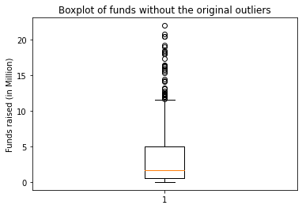

```python
plot = plt.boxplot(modified.Funds_in_million)
plt.title('Boxplot of funds without the original outliers')
plt.ylabel("Funds raised (in Million)")
plt.show()
```

```python
modified.OperatingState.value_counts()
```

```
Operating    275
Closed        56
Acquired      55
Name: OperatingState, dtype: int64
```

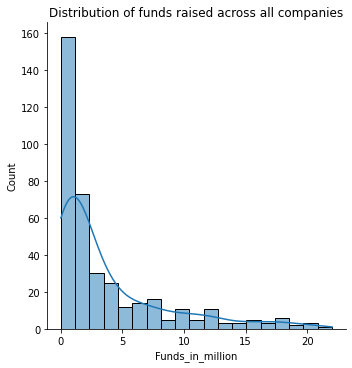

```python
sns.displot(modified.Funds_in_million, kde=True)
plt.title('Distribution of funds raised across all companies')
plt.show()
```

```python
modified.Funds_in_million.describe()
```

```
count    386.00000
mean       3.72514
std        4.73236
min        0.00500
25%        0.60000
50%        1.70000
75%        5.00000
max       22.00000
Name: Funds_in_million, dtype: float64
```

- Even after removing the outliers, the data is pretty heavily skewed

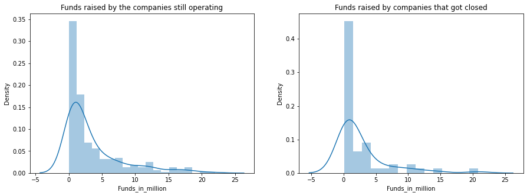

```python
fig, ax = plt.subplots(1, 2)

fig.set_figheight(5)
fig.set_figwidth(15)

sns.distplot(modified.loc[modified.OperatingState == 'Operating', 'Funds_in_million'], ax = ax[0])
sns.distplot(modified.loc[modified.OperatingState =='Closed', 'Funds_in_million'], ax = ax[1])

ax[0].set_title('Funds raised by the companies still operating')
ax[1].set_title('Funds raised by companies that got closed')
plt.show()
```

- Visually the distributions are quiet similar
- To prove if there is a significant difference or not we will have to perform a hypothesis test
- Since we want to compare the difference in means of the samples, we can either use 2 sample t test or z-test
- For this exercise we shall do both and compare the results
- One thing to notice is that the distributions are not normal yet, since our sample size is reasonably big ( >30 samples), we will go ahead with the aforementioned tests

For the first test,

**Null hypothesis (Ho)** : There is no difference between the two means

**Alternate hypothesis (Ha)** : There is significant difference between the two means

```python
# perform a z-test

sample1 = modified.loc[modified.OperatingState == 'Operating', 'Funds_in_million']
sample2 = modified.loc[modified.OperatingState =='Closed', 'Funds_in_million']

alpha = 0.05

test_statistic, p_value = ztest(sample1, sample2)

if p_value <= alpha:
    print(f'Since the p-value, {round(p_value, 3)} < {alpha} (alpha) the difference is significant and we reject the Null hypothesis')
else:
    print(f'''\t Since the p-value, {round(p_value,3)} > {alpha} (alpha) the difference is not significant and,
    \t we fail to reject the Null hypothesis''')
```

```
	 Since the p-value, 0.192 > 0.05 (alpha) the difference is not significant and,
    	 we fail to reject the Null hypothesis
```

- We can perform t test independent also

```python
test_statistic, p_value = ttest_ind(sample1, sample2)

if p_value <= alpha:
    print(f'Since the p-value, {round(p_value, 3)} < {alpha} (alpha) the difference is significant and we reject the Null hypothesis')
else:
    print(f'''\t Since the p-value, {round(p_value,3)} > {alpha} (alpha) the difference is not significant and,
    \t we fail to reject the Null hypothesis''')
```

```
	 Since the p-value, 0.193 > 0.05 (alpha) the difference is not significant and,
    	 we fail to reject the Null hypothesis
```

- From the tests above we found no evidence to state that the companies that have raised more money tend to suceed more or vice-versa

## ----------------------------------------------------------------------------------

### Make a copy of original dataset and do the below

- Check frequency distribution of Result variable.
- Calculate percentage of winners that are still operating and percentage of contestants that are still operating
- Write your hypothesis comparing the proportion of companies that are operating between winners and contestants: Write the null hypothesis and alternative hypothesis. Test for significance and conclusion
- Check distribution of the Event variable.
- Select only the Event that has disrupt keyword from 2013 onwards.
- Write and perform your hypothesis along with significance test comparing the funds raised by companies across NY, SF and EU events from 2013 onwards.
- Plot the distribution plot comparing the 3 city events.

```python
mod=company.copy(deep = True)
mod.head()
```

|  | Startup | Product | Funding | Event | Result | OperatingState |
| --- | --- | --- | --- | --- | --- | --- |
| 0 | 2600Hz | 2600hz.com | NaN | Disrupt SF 2013 | Contestant | Operating |
| 1 | 3DLT | 3dlt.com | $630K | Disrupt NYC 2013 | Contestant | Closed |
| 2 | 3DPrinterOS | 3dprinteros.com | NaN | Disrupt SF 2016 | Contestant | Operating |
| 3 | 3Dprintler | 3dprintler.com | $1M | Disrupt NY 2016 | Audience choice | Operating |
| 4 | 42 Technologies | 42technologies.com | NaN | Disrupt NYC 2013 | Contestant | Operating |

```python
mod.Result.value_counts()
```

```
Contestant         488
Finalist            84
Audience choice     41
Winner              26
Runner up           23
Name: Result, dtype: int64
```

```python
winners = mod.Result.value_counts()[1:].sum()
contestants = mod.Result.value_counts()['Contestant']
winners,contestants
```

```
(174, 488)
```

```python
contestants_operating = mod.OperatingState[mod.Result == 'Contestant'].value_counts().loc['Operating']
winners_operating = mod.OperatingState[mod.Result != 'Contestant'].value_counts().loc['Operating']
winners_operating,contestants_operating
```

```
(133, 332)
```

```python
print('percentage of winners that are still operating ', winners_operating/winners)
print('percentage of contestants that are still operating ', contestants_operating/contestants)
```

```
percentage of winners that are still operating  0.764367816091954
percentage of contestants that are still operating  0.680327868852459
```

**Null hyputhesis (Ho)**: The proportion of companies that are operating is the same in both categories - winners and contestants

**Alternative hypothesis (Ha)**: The proportion of companies that are operating is significantly different from each other, among the two categories

```python
p_value = proportions_chisquare([contestants_operating, winners_operating], [contestants, winners])
print(p_value[1])
if p_value[1] <= alpha:
    print(f'Since the p-value, {round(p_value[1], 3)} < {alpha} (alpha) the difference is significant and we reject the Null hypothesis')
else:
    print(f'''\t Since the p-value, {round(p_value[1],3)} > {alpha} (alpha) the difference is not significant and,
    \t we fail to reject the Null hypothesis''')
```

```
0.03736043198454715
Since the p-value, 0.037 < 0.05 (alpha) the difference is significant and we reject the Null hypothesis
```

- Check distribution of the Event variable.
- Select only the Event that has disrupt keyword from 2013 onwards.
- Write and perform your hypothesis along with significance test comparing the funds raised by companies across NY, SF and EU events from 2013 onwards.
- Plot the distribution plot comparing the 3 city events

```python
modified[mod.Event.apply(lambda x: 'Disrupt' in x)].Event.value_counts()
```

```
Disrupt NY 2015         21
Disrupt SF 2011         19
Disrupt SF 2014         19
Disrupt NYC 2012        19
Disrupt SF 2015         19
Disrupt NYC 2013        19
Disrupt SF 2013         19
Disrupt SF 2016         17
Disrupt NY 2016         16
Disrupt SF 2012         15
Disrupt NYC 2014        15
Disrupt NYC 2011        15
Disrupt SF 2010         13
Disrupt London 2015     11
Disrupt London 2016     10
Disrupt NYC 2010        10
Disrupt EU 2014         10
Disrupt EU 2013          9
Disrupt Beijing 2011     4
Name: Event, dtype: int64
```

```python
events = modified[modified.Event.apply(lambda x: 'Disrupt' in x and int(x[-4:]) > 2012)].Event  # all the events of relevance
events
```

```
1         Disrupt NYC 2013
3          Disrupt NY 2016
13         Disrupt SF 2015
14     Disrupt London 2016
16         Disrupt SF 2015
              ...
635        Disrupt NY 2015
641       Disrupt NYC 2013
642        Disrupt SF 2014
646    Disrupt London 2015
660        Disrupt SF 2013
Name: Event, Length: 185, dtype: object
```

```python
NY = modified.loc[events[events.apply(lambda x: 'NY' in x)].index, 'Funds_in_million']
SF = modified.loc[events[events.apply(lambda x: 'SF' in x)].index, 'Funds_in_million']
EU = modified.loc[events[events.apply(lambda x: 'EU' in x or 'London' in x)].index, 'Funds_in_million']
print(len(NY), len(SF), len(EU))
```

```
71 74 40
```

**Null Hypothesis(Ho)**: Average funds raised by companies across three cities are the same

**Alternative Hypothesis(Ha)**: Average funds raised by companies across three cities are the different

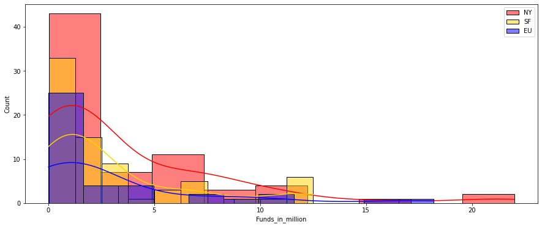

```python
plt.figure(figsize=(15,6))
sns.histplot(NY, color = 'Red', label = 'NY',kde= True)
sns.histplot(SF, color = 'Gold', label = 'SF',kde= True)
sns.histplot(EU, color = 'blue', label = 'EU',kde= True)
plt.legend()
plt.show()
```

```python
stat, p_value = f_oneway(NY, SF, EU)

if p_value <= alpha:
    print(f'Since the p-value, {round(p_value, 3)} < {alpha} (alpha) the difference is significant and we reject the Null hypothesis')
else:
    print(f'''\t Since the p-value, {round(p_value,3)} > {alpha} (alpha) the difference is not significant and,
    \t we fail to reject the Null hypothesis''')
```

```
	 Since the p-value, 0.628 > 0.05 (alpha) the difference is not significant and,
    	 we fail to reject the Null hypothesis
```